# How Does cyclistic Bike-Share Navigate Speedy Success?

## Stage 1

## Business understanding

Cyclistic is bike sharing company based on Chicago it has 5,824 bicycles that are geo tracked and locked into a network of 692 stations.

cyclistic has two kind of customers casual riders who purchase bike for single ride or full day pass and another kind of customer is member rider who purchase annual membership

## Business task

Cyclistic's finance analysts have concluded that annual members are much more profitable than casual riders. Although the pricing flexibility helps Cyclistic attract more customers, Moreno(The director of marketing) believes that maximizing the number of annual members will be key to future growth. Rather than creating a marketing campaign that targets all-new customers, Moreno believes there is a very good chance to convert casual riders into members.

#### Breaking down business task into problum statement for further understading

```
 Three questions will guide the future marketing program
 1. How do annual members and casual riders use Cyclistic bikes Differently?
 2. Why would casual riders buy Cyclistic annual memberships?
 3. How can Cyclistic use digital media to influence casual riders to become members?
```

### Problem assigned us to solve

#### How do annual members and casual riders use Cyclistic bikes differently?

## Stage 2

## Prepare data for exploration

```
After understanding business task we move to colect,organize,store and check the crediblity of data
```

#### Key task of prepare stage

```
1.Download data and store it appropriately.

2.Identify how its organized.

3.Short and filter data

4.Determine the credibility of data
```

### Download data and store it appropriately

```
 Cyclistic Recent 12 month bike ride data has been downloaded from here
 <https://divvy-tripdata.s3.amazonaws.com/index.html>

 Data has been stored properly on respective path
 C:\Users\sachi\OneDrive\Desktop\Case Study_Bike_Share\Bike_Share_12_month_data\Original_data_files
```

### Identify how data is orgenized need to import data sets to R studio

```
 Installing tidyverse pakage which is esensial for data analysis in R
```

```r
install.packages("tidyverse")
```

```r
library(tidyverse)
```

### Importing cvs files

```r
df1=read.csv("C:/Users/sachi/OneDrive/Desktop/Case Study_ Bike_Share/Bike_Share_12_month_data/Original_data_files/2021-04-divvy-tripdata.csv")

df2=read.csv("C:/Users/sachi/OneDrive/Desktop/Case Study_ Bike_Share/Bike_Share_12_month_data/Original_data_files/2021-05-divvy-tripdata.csv")

df3=read.csv("C:/Users/sachi/OneDrive/Desktop/Case Study_ Bike_Share/Bike_Share_12_month_data/Original_data_files/2021-06-divvy-tripdata.csv")

df4=read.csv("C:/Users/sachi/OneDrive/Desktop/Case Study_ Bike_Share/Bike_Share_12_month_data/Original_data_files/2021-07-divvy-tripdata.csv")

df5=read.csv("C:/Users/sachi/OneDrive/Desktop/Case Study_ Bike_Share/Bike_Share_12_month_data/Original_data_files/2021-08-divvy-tripdata.csv")

df6=read.csv("C:/Users/sachi/OneDrive/Desktop/Case Study_ Bike_Share/Bike_Share_12_month_data/Original_data_files/2021-09-divvy-tripdata.csv")

df7=read.csv("C:/Users/sachi/OneDrive/Desktop/Case Study_ Bike_Share/Bike_Share_12_month_data/Original_data_files/2021-10-divvy-tripdata.csv")

df8=read.csv("C:/Users/sachi/OneDrive/Desktop/Case Study_ Bike_Share/Bike_Share_12_month_data/Original_data_files/2021-11-divvy-tripdata.csv")

df9=read.csv("C:/Users/sachi/OneDrive/Desktop/Case Study_ Bike_Share/Bike_Share_12_month_data/Original_data_files/2021-12-divvy-tripdata.csv")

df10=read.csv("C:/Users/sachi/OneDrive/Desktop/Case Study_ Bike_Share/Bike_Share_12_month_data/Original_data_files/2022-01-divvy-tripdata.csv")

df11=read.csv("C:/Users/sachi/OneDrive/Desktop/Case Study_ Bike_Share/Bike_Share_12_month_data/Original_data_files/2022-02-divvy-tripdata.csv")

df12=read.csv("C:/Users/sachi/OneDrive/Desktop/Case Study_ Bike_Share/Bike_Share_12_month_data/Original_data_files/2021-03-divvy-tripdata.csv")
```

```r
head(df1)
```

| ride_id | rideable_type | started_at | ended_at | start_station_name | start_station_id | end_station_name | end_station_id | start_lat | start_lng | end_lat | end_lng | member_casual |
| --- | --- | --- | --- | --- | --- | --- | --- | --- | --- | --- | --- | --- |
| 6C992BD37A98A63F | classic_bike | 2021-04-12 18:25:36 | 2021-04-12 18:56:55 | State St & Pearson St | TA1307000061 | Southport Ave & Waveland Ave | 13235 | 41.89745 | -87.62872 | 41.94815 | -87.66394 | member |
| 1E0145613A209000 | docked_bike | 2021-04-27 17:27:11 | 2021-04-27 18:31:29 | Dorchester Ave & 49th St | KA1503000069 | Dorchester Ave & 49th St | KA1503000069 | 41.80577 | -87.59246 | 41.80577 | -87.59246 | casual |
| E498E15508A80BAD | docked_bike | 2021-04-03 12:42:45 | 2021-04-07 11:40:24 | Loomis Blvd & 84th St | 20121 | Loomis Blvd & 84th St | 20121 | 41.74149 | -87.65841 | 41.74149 | -87.65841 | casual |
| 1887262AD101C604 | classic_bike | 2021-04-17 09:17:42 | 2021-04-17 09:42:48 | Honore St & Division St | TA1305000034 | Southport Ave & Waveland Ave | 13235 | 41.90312 | -87.67394 | 41.94815 | -87.66394 | member |
| C123548CAB2A32A5 | docked_bike | 2021-04-03 12:42:25 | 2021-04-03 14:13:42 | Loomis Blvd & 84th St | 20121 | Loomis Blvd & 84th St | 20121 | 41.74149 | -87.65841 | 41.74149 | -87.65841 | casual |
| 097E76F3651B1AC1 | classic_bike | 2021-04-25 18:43:18 | 2021-04-25 18:43:59 | Clinton St & Polk St | 15542 | Clinton St & Polk St | 15542 | 41.87147 | -87.64095 | 41.87147 | -87.64095 | casual |

### Understanding dataset

```r
colnames(df1)
```

1. 'ride_id'

2. 'rideable_type'

3. 'started_at'

4. 'ended_at'

5. 'start_station_name'

6. 'start_station_id'

7. 'end_station_name'

8. 'end_station_id'

9. 'start_lat'

10. 'start_lng'

11. 'end_lat'

12. 'end_lng'

13. 'member_casual'

```r
colnames(df11)
```

1. 'ride_id'

2. 'rideable_type'

3. 'started_at'

4. 'ended_at'

5. 'start_station_name'

6. 'start_station_id'

7. 'end_station_name'

8. 'end_station_id'

9. 'start_lat'

10. 'start_lng'

11. 'end_lat'

12. 'end_lng'

13. 'member_casual'

### Comparing column name of datasets to combine all datasets

```
isntalling required package
```

```r
install.packages("janitor")
```

```r
library(janitor)
```

### Comparing dataset columns

```r
compare_df_cols(df1,df2,df3,df4,df5,df6,df7,df8,df9,df10,df11,df12)
```

| column_name | df1 | df2 | df3 | df4 | df5 | df6 | df7 | df8 | df9 | df10 | df11 | df12 |
| --- | --- | --- | --- | --- | --- | --- | --- | --- | --- | --- | --- | --- |
| end_lat | numeric | numeric | numeric | numeric | numeric | numeric | numeric | numeric | numeric | numeric | numeric | numeric |
| end_lng | numeric | numeric | numeric | numeric | numeric | numeric | numeric | numeric | numeric | numeric | numeric | numeric |
| end_station_id | factor | factor | factor | factor | factor | factor | factor | factor | factor | factor | factor | factor |
| end_station_name | factor | factor | factor | factor | factor | factor | factor | factor | factor | factor | factor | factor |
| ended_at | factor | factor | factor | factor | factor | factor | factor | factor | factor | factor | factor | factor |
| member_casual | factor | factor | factor | factor | factor | factor | factor | factor | factor | factor | factor | factor |
| ride_id | factor | factor | factor | factor | factor | factor | factor | factor | factor | factor | factor | factor |
| rideable_type | factor | factor | factor | factor | factor | factor | factor | factor | factor | factor | factor | factor |
| start_lat | numeric | numeric | numeric | numeric | numeric | numeric | numeric | numeric | numeric | numeric | numeric | numeric |
| start_lng | numeric | numeric | numeric | numeric | numeric | numeric | numeric | numeric | numeric | numeric | numeric | numeric |
| start_station_id | factor | factor | factor | factor | factor | factor | factor | factor | factor | factor | factor | factor |
| start_station_name | factor | factor | factor | factor | factor | factor | factor | factor | factor | factor | factor | factor |
| started_at | factor | factor | factor | factor | factor | factor | factor | factor | factor | factor | factor | factor |

#### Each dataset has similiral colums and similar data type so its appropriate to combine all ataset

### Combining datasests

```r
union_df=rbind(df1,df2,df3,df4,df5,df6,df7,df8,df9,df10,df11,df12)
```

```r
head(union_df)
```

| ride_id | rideable_type | started_at | ended_at | start_station_name | start_station_id | end_station_name | end_station_id | start_lat | start_lng | end_lat | end_lng | member_casual |
| --- | --- | --- | --- | --- | --- | --- | --- | --- | --- | --- | --- | --- |
| 6C992BD37A98A63F | classic_bike | 2021-04-12 18:25:36 | 2021-04-12 18:56:55 | State St & Pearson St | TA1307000061 | Southport Ave & Waveland Ave | 13235 | 41.89745 | -87.62872 | 41.94815 | -87.66394 | member |
| 1E0145613A209000 | docked_bike | 2021-04-27 17:27:11 | 2021-04-27 18:31:29 | Dorchester Ave & 49th St | KA1503000069 | Dorchester Ave & 49th St | KA1503000069 | 41.80577 | -87.59246 | 41.80577 | -87.59246 | casual |
| E498E15508A80BAD | docked_bike | 2021-04-03 12:42:45 | 2021-04-07 11:40:24 | Loomis Blvd & 84th St | 20121 | Loomis Blvd & 84th St | 20121 | 41.74149 | -87.65841 | 41.74149 | -87.65841 | casual |
| 1887262AD101C604 | classic_bike | 2021-04-17 09:17:42 | 2021-04-17 09:42:48 | Honore St & Division St | TA1305000034 | Southport Ave & Waveland Ave | 13235 | 41.90312 | -87.67394 | 41.94815 | -87.66394 | member |
| C123548CAB2A32A5 | docked_bike | 2021-04-03 12:42:25 | 2021-04-03 14:13:42 | Loomis Blvd & 84th St | 20121 | Loomis Blvd & 84th St | 20121 | 41.74149 | -87.65841 | 41.74149 | -87.65841 | casual |
| 097E76F3651B1AC1 | classic_bike | 2021-04-25 18:43:18 | 2021-04-25 18:43:59 | Clinton St & Polk St | 15542 | Clinton St & Polk St | 15542 | 41.87147 | -87.64095 | 41.87147 | -87.64095 | casual |

```r
tail(union_df)
```

|  | ride_id | rideable_type | started_at | ended_at | start_station_name | start_station_id | end_station_name | end_station_id | start_lat | start_lng | end_lat | end_lng | member_casual |
| --- | --- | --- | --- | --- | --- | --- | --- | --- | --- | --- | --- | --- | --- |
| 5667981 | 081549DEA616CA22 | electric_bike | 2021-03-14 01:59:38 | 2021-03-14 03:13:09 | Larrabee St & Armitage Ave | TA1309000006 | New St & Illinois St | TA1306000013 | 41.91813 | -87.64375 | 41.89081 | -87.61878 | member |
| 5667982 | 9397BDD14798A1BA | docked_bike | 2021-03-20 14:58:56 | 2021-03-20 17:22:47 | Michigan Ave & Oak St | 13042 | New St & Illinois St | TA1306000013 | 41.90096 | -87.62378 | 41.89085 | -87.61862 | casual |
| 5667983 | BBBEB8D51AAD40DA | classic_bike | 2021-03-02 11:35:10 | 2021-03-02 11:43:37 | Kingsbury St & Kinzie St | KA1503000043 | New St & Illinois St | TA1306000013 | 41.88918 | -87.63851 | 41.89085 | -87.61862 | member |
| 5667984 | 637FF754DA0BD9E1 | classic_bike | 2021-03-09 11:07:36 | 2021-03-09 11:49:11 | Michigan Ave & Oak St | 13042 | Clark St & Berwyn Ave | KA1504000146 | 41.90096 | -87.62378 | 41.97800 | -87.66805 | member |
| 5667985 | F8F43A0B978A7A35 | classic_bike | 2021-03-01 18:11:57 | 2021-03-01 18:18:37 | Kingsbury St & Kinzie St | KA1503000043 | New St & Illinois St | TA1306000013 | 41.88918 | -87.63851 | 41.89085 | -87.61862 | member |
| 5667986 | 3AE64EA5BF43CF72 | electric_bike | 2021-03-26 17:58:14 | 2021-03-26 18:06:43 |  |  | New St & Illinois St | TA1306000013 | 41.88000 | -87.63000 | 41.89082 | -87.61954 | member |

### Determine the credibility of data we use ROCCC method to identify data credibility

#### R & O - Reliable and original: Data is originaly collected by cyclistic its primary source and original

#### C-Comprehensive : Data has important formation to solve problem so its comprehensive

#### C- Current : Data is not outdated its current data

#### C- Cited : As data is maintained and trusted by cyclistic its cited data

## Stage 3

## Process

Process stage is very important in data analytics because here data will get cleaned and transpormed for analysis stage clean and transpormed data is key for accurate analysis

### Key tasks of process stage

```
1. Check for errors in data

2.Check for duplicate data

3.Treat null values

4.Orgenize and format data

5.perform calculations

6.Derived metrics or new metrics
```

### Installing packages for data cleaning and data overview

```r
install.packages("readr")
install.packages("dplyr")
library(readr)
library(dplyr)
```

[output not shown]

[output not shown]

```r
install.packages("skimr")
install.packages("here")
library(skimr)
library(here)
```

```r
library(lubridate)
```

#### Checking for error , duplicate and treat null values

```r
skim_without_charts(union_df)
```

```
-- Data Summary ------------------------
                           Values
Name                       union_df
Number of rows             5667986
Number of columns          13
_______________________
Column type frequency:
  factor                   9
  numeric                  4
________________________
Group variables            None

-- Variable type: factor -------------------------------------------------------
# A tibble: 9 x 6
  skim_variable      n_missing complete_rate ordered n_unique
* <chr>                  <int>         <dbl> <lgl>      <int>
1 ride_id                    0             1 FALSE    5667986
2 rideable_type              0             1 FALSE          3
3 started_at                 0             1 FALSE    4747127
4 ended_at                   0             1 FALSE    4740417
5 start_station_name         0             1 FALSE        854
6 start_station_id           0             1 FALSE        845
7 end_station_name           0             1 FALSE        855
8 end_station_id             0             1 FALSE        847
9 member_casual              0             1 FALSE          2
  top_counts
* <chr>
1 000: 1, 000: 1, 000: 1, 000: 1
2 cla: 3268797, ele: 2087901, doc: 311288
3 202: 7, 202: 7, 202: 7, 202: 7
4 202: 17, 202: 16, 202: 15, 202: 14
5 emp: 712978, Str: 82954, Mic: 44409, Wel: 43969
6 emp: 712975, 130: 82954, LF-: 47856, 133: 46176
7 emp: 761817, Str: 83648, Mic: 44913, Wel: 44149
8 emp: 761817, 130: 83648, LF-: 53932, 130: 44913
9 mem: 3127293, cas: 2540693

-- Variable type: numeric ------------------------------------------------------
# A tibble: 4 x 10
  skim_variable n_missing complete_rate  mean     sd    p0   p25   p50   p75
* <chr>             <int>         <dbl> <dbl>  <dbl> <dbl> <dbl> <dbl> <dbl>
1 start_lat             0         1      41.9 0.0463  41.6  41.9  41.9  41.9
2 start_lng             0         1     -87.6 0.0295 -87.8 -87.7 -87.6 -87.6
3 end_lat            4617         0.999  41.9 0.0463  41.4  41.9  41.9  41.9
4 end_lng            4617         0.999 -87.6 0.0291 -89.0 -87.7 -87.6 -87.6
   p100
* <dbl>
1  45.6
2 -73.8
3  42.2
4 -87.5
```

```r
union_df%>%
    distinct(.keep_all = TRUE) %>%
    skim_without_charts()
```

```
-- Data Summary ------------------------
                           Values
Name                       Piped data
Number of rows             5667986
Number of columns          13
_______________________
Column type frequency:
  factor                   9
  numeric                  4
________________________
Group variables            None

-- Variable type: factor -------------------------------------------------------
# A tibble: 9 x 6
  skim_variable      n_missing complete_rate ordered n_unique
* <chr>                  <int>         <dbl> <lgl>      <int>
1 ride_id                    0             1 FALSE    5667986
2 rideable_type              0             1 FALSE          3
3 started_at                 0             1 FALSE    4747127
4 ended_at                   0             1 FALSE    4740417
5 start_station_name         0             1 FALSE        854
6 start_station_id           0             1 FALSE        845
7 end_station_name           0             1 FALSE        855
8 end_station_id             0             1 FALSE        847
9 member_casual              0             1 FALSE          2
  top_counts
* <chr>
1 000: 1, 000: 1, 000: 1, 000: 1
2 cla: 3268797, ele: 2087901, doc: 311288
3 202: 7, 202: 7, 202: 7, 202: 7
4 202: 17, 202: 16, 202: 15, 202: 14
5 emp: 712978, Str: 82954, Mic: 44409, Wel: 43969
6 emp: 712975, 130: 82954, LF-: 47856, 133: 46176
7 emp: 761817, Str: 83648, Mic: 44913, Wel: 44149
8 emp: 761817, 130: 83648, LF-: 53932, 130: 44913
9 mem: 3127293, cas: 2540693

-- Variable type: numeric ------------------------------------------------------
# A tibble: 4 x 10
  skim_variable n_missing complete_rate  mean     sd    p0   p25   p50   p75
* <chr>             <int>         <dbl> <dbl>  <dbl> <dbl> <dbl> <dbl> <dbl>
1 start_lat             0         1      41.9 0.0463  41.6  41.9  41.9  41.9
2 start_lng             0         1     -87.6 0.0295 -87.8 -87.7 -87.6 -87.6
3 end_lat            4617         0.999  41.9 0.0463  41.4  41.9  41.9  41.9
4 end_lng            4617         0.999 -87.6 0.0291 -89.0 -87.7 -87.6 -87.6
   p100
* <dbl>
1  45.6
2 -73.8
3  42.2
4 -87.5
```

#### When we execute both skim_without_charts(union_df) and union_df %>% distinct(.keep_all = TRUE) %>% kim_without_charts() rows count remain same 5667986 so we finaliesed there is no duplicate rows in dataset and missing values in end_lat and end_lang kept on.

### New metrics creation and calculations

#### Dealing with dates

```
 we have already loaded lubridate library to deal with dates
```

#### Assigning datafrme to new varible to prevent it from crash during transformation

```r
new_df=union_df
```

#### Checking data type of date column

```r
class(new_df$started_at)
class(new_df$ended_at)
```

'factor'

'factor'

#### Covertion of factor into 'POSIXct' 'POSIXt'(these are date formate includes for ymd_hms) format

```r
new_df$started_at=ymd_hms(new_df$started_at)
new_df$ended_at=ymd_hms(new_df$ended_at)
```

```r
class(new_df$started_at)
class(new_df$ended_at)
```

1. 'POSIXct'

2. 'POSIXt'

1. 'POSIXct'

2. 'POSIXt'

Now its ready to extract date and time related information from this columns

Extraction of day name into new coumns weekday as per our bussiness task we might require weekday from started_at column

```r
new_df$weekday=weekdays(new_df$started_at)
```

Month name extaction month column

```r
new_df$month=months(new_df$started_at)
```

```r
month=months(new_df$started_at)
```

```r
str(new_df)

# weekday and month has been added to dataframe
```

```
'data.frame':	5667986 obs. of  15 variables:
 $ ride_id           : Factor w/ 5667986 levels "00001A81D056B01B",..: 143082 39569 300958 32373 254792 12428 110411 280871 145203 5400 ...
 $ rideable_type     : Factor w/ 3 levels "classic_bike",..: 1 2 2 1 2 1 1 3 1 1 ...
 $ started_at        : POSIXct, format: "2021-04-12 18:25:36" "2021-04-27 17:27:11" ...
 $ ended_at          : POSIXct, format: "2021-04-12 18:56:55" "2021-04-27 18:31:29" ...
 $ start_station_name: Factor w/ 854 levels "","2112 W Peterson Ave",..: 579 221 402 309 402 160 19 221 19 221 ...
 $ start_station_id  : Factor w/ 845 levels "","13001","13006",..: 572 438 242 541 242 148 210 438 210 438 ...
 $ end_station_name  : Factor w/ 855 levels "","2112 W Peterson Ave",..: 559 219 400 559 400 158 18 219 18 219 ...
 $ end_station_id    : Factor w/ 847 levels "","13001","13006",..: 81 438 242 81 242 148 210 438 210 438 ...
 $ start_lat         : num  41.9 41.8 41.7 41.9 41.7 ...
 $ start_lng         : num  -87.6 -87.6 -87.7 -87.7 -87.7 ...
 $ end_lat           : num  41.9 41.8 41.7 41.9 41.7 ...
 $ end_lng           : num  -87.7 -87.6 -87.7 -87.7 -87.7 ...
 $ member_casual     : Factor w/ 2 levels "casual","member": 2 1 1 2 1 1 1 1 1 1 ...
 $ weekday           : chr  "Monday" "Tuesday" "Saturday" "Saturday" ...
 $ month             : chr  "April" "April" "April" "April" ...
```

```r
new_df$weekend_weekday=ifelse(new_df$weekday==c("Saturday","Sunday"),"weekend","weekday")
```

```r
str(new_df)
```

```
'data.frame':	5667986 obs. of  16 variables:
 $ ride_id           : Factor w/ 5667986 levels "00001A81D056B01B",..: 143082 39569 300958 32373 254792 12428 110411 280871 145203 5400 ...
 $ rideable_type     : Factor w/ 3 levels "classic_bike",..: 1 2 2 1 2 1 1 3 1 1 ...
 $ started_at        : POSIXct, format: "2021-04-12 18:25:36" "2021-04-27 17:27:11" ...
 $ ended_at          : POSIXct, format: "2021-04-12 18:56:55" "2021-04-27 18:31:29" ...
 $ start_station_name: Factor w/ 854 levels "","2112 W Peterson Ave",..: 579 221 402 309 402 160 19 221 19 221 ...
 $ start_station_id  : Factor w/ 845 levels "","13001","13006",..: 572 438 242 541 242 148 210 438 210 438 ...
 $ end_station_name  : Factor w/ 855 levels "","2112 W Peterson Ave",..: 559 219 400 559 400 158 18 219 18 219 ...
 $ end_station_id    : Factor w/ 847 levels "","13001","13006",..: 81 438 242 81 242 148 210 438 210 438 ...
 $ start_lat         : num  41.9 41.8 41.7 41.9 41.7 ...
 $ start_lng         : num  -87.6 -87.6 -87.7 -87.7 -87.7 ...
 $ end_lat           : num  41.9 41.8 41.7 41.9 41.7 ...
 $ end_lng           : num  -87.7 -87.6 -87.7 -87.7 -87.7 ...
 $ member_casual     : Factor w/ 2 levels "casual","member": 2 1 1 2 1 1 1 1 1 1 ...
 $ weekday           : chr  "Monday" "Tuesday" "Saturday" "Saturday" ...
 $ month             : chr  "April" "April" "April" "April" ...
 $ weekend_weekday   : chr  "weekday" "weekday" "weekend" "weekday" ...
```

Creating New column called duration_hr substracting from ended_at from started_at

```r
new_df$duration_hr=round(difftime(new_df$ended_at,new_df$started_at,units="hours"),digits = 2)
```

```r
str(new_df)
```

```
'data.frame':	5667986 obs. of  17 variables:
 $ ride_id           : Factor w/ 5667986 levels "00001A81D056B01B",..: 143082 39569 300958 32373 254792 12428 110411 280871 145203 5400 ...
 $ rideable_type     : Factor w/ 3 levels "classic_bike",..: 1 2 2 1 2 1 1 3 1 1 ...
 $ started_at        : POSIXct, format: "2021-04-12 18:25:36" "2021-04-27 17:27:11" ...
 $ ended_at          : POSIXct, format: "2021-04-12 18:56:55" "2021-04-27 18:31:29" ...
 $ start_station_name: Factor w/ 854 levels "","2112 W Peterson Ave",..: 579 221 402 309 402 160 19 221 19 221 ...
 $ start_station_id  : Factor w/ 845 levels "","13001","13006",..: 572 438 242 541 242 148 210 438 210 438 ...
 $ end_station_name  : Factor w/ 855 levels "","2112 W Peterson Ave",..: 559 219 400 559 400 158 18 219 18 219 ...
 $ end_station_id    : Factor w/ 847 levels "","13001","13006",..: 81 438 242 81 242 148 210 438 210 438 ...
 $ start_lat         : num  41.9 41.8 41.7 41.9 41.7 ...
 $ start_lng         : num  -87.6 -87.6 -87.7 -87.7 -87.7 ...
 $ end_lat           : num  41.9 41.8 41.7 41.9 41.7 ...
 $ end_lng           : num  -87.7 -87.6 -87.7 -87.7 -87.7 ...
 $ member_casual     : Factor w/ 2 levels "casual","member": 2 1 1 2 1 1 1 1 1 1 ...
 $ weekday           : chr  "Monday" "Tuesday" "Saturday" "Saturday" ...
 $ month             : chr  "April" "April" "April" "April" ...
 $ weekend_weekday   : chr  "weekday" "weekday" "weekend" "weekday" ...
 $ duration_hr       : 'difftime' num  0.52 1.07 94.96 0.42 ...
  ..- attr(*, "units")= chr "hours"
```

```r
head(new_df)
```

| ride_id | rideable_type | started_at | ended_at | start_station_name | start_station_id | end_station_name | end_station_id | start_lat | start_lng | end_lat | end_lng | member_casual | weekday | month | weekend_weekday | duration_hr |
| --- | --- | --- | --- | --- | --- | --- | --- | --- | --- | --- | --- | --- | --- | --- | --- | --- |
| 6C992BD37A98A63F | classic_bike | 2021-04-12 18:25:36 | 2021-04-12 18:56:55 | State St & Pearson St | TA1307000061 | Southport Ave & Waveland Ave | 13235 | 41.89745 | -87.62872 | 41.94815 | -87.66394 | member | Monday | April | weekday | 0.52 hours |
| 1E0145613A209000 | docked_bike | 2021-04-27 17:27:11 | 2021-04-27 18:31:29 | Dorchester Ave & 49th St | KA1503000069 | Dorchester Ave & 49th St | KA1503000069 | 41.80577 | -87.59246 | 41.80577 | -87.59246 | casual | Tuesday | April | weekday | 1.07 hours |
| E498E15508A80BAD | docked_bike | 2021-04-03 12:42:45 | 2021-04-07 11:40:24 | Loomis Blvd & 84th St | 20121 | Loomis Blvd & 84th St | 20121 | 41.74149 | -87.65841 | 41.74149 | -87.65841 | casual | Saturday | April | weekend | 94.96 hours |
| 1887262AD101C604 | classic_bike | 2021-04-17 09:17:42 | 2021-04-17 09:42:48 | Honore St & Division St | TA1305000034 | Southport Ave & Waveland Ave | 13235 | 41.90312 | -87.67394 | 41.94815 | -87.66394 | member | Saturday | April | weekday | 0.42 hours |
| C123548CAB2A32A5 | docked_bike | 2021-04-03 12:42:25 | 2021-04-03 14:13:42 | Loomis Blvd & 84th St | 20121 | Loomis Blvd & 84th St | 20121 | 41.74149 | -87.65841 | 41.74149 | -87.65841 | casual | Saturday | April | weekend | 1.52 hours |
| 097E76F3651B1AC1 | classic_bike | 2021-04-25 18:43:18 | 2021-04-25 18:43:59 | Clinton St & Polk St | 15542 | Clinton St & Polk St | 15542 | 41.87147 | -87.64095 | 41.87147 | -87.64095 | casual | Sunday | April | weekend | 0.01 hours |

## Stage 4

## Analyze

#### Analyse is detective kind of task in data analysis journey. During analysis we will discover trend,pattern and relation in dataset

#### Our analyze step should move with considering our business task understand difference between casual rider and member rider

| member_casual | rider_count |
| --- | --- |
| casual | 2540693 |
| member | 3127293 |

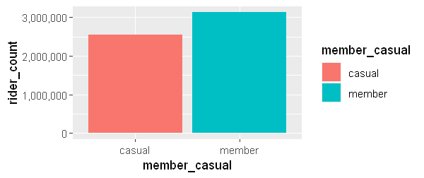

```r
# number of casul and menber riders
new_df %>%
      group_by(member_casual) %>%
      summarise(rider_count = n())
options(repr.plot.width = 5, repr.plot.height = 2.1)
new_df %>%
      group_by(member_casual) %>%
      summarise(rider_count = n())%>%
      ggplot()+
      geom_col(mapping = aes(x=member_casual,y=rider_count,fill=member_casual))+
      scale_y_continuous(labels = comma)
```

#### Cyclistic has more member riders than casual riders

| member_casual | ride_duration |
| --- | --- |
| casual | 1351640.7 hours |
| member | 702795.9 hours |

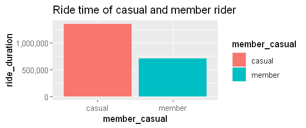

```r
#ride time of casual and member rider

new_df %>%
      group_by(member_casual) %>%
      summarise(ride_duration=sum(duration_hr))

options(repr.plot.width = 5, repr.plot.height = 2.1)
new_df %>%
      group_by(member_casual) %>%
      summarise(ride_duration=sum(duration_hr))%>%
      ggplot()+
      geom_col(mapping = aes(x=member_casual,y=ride_duration,fill=member_casual)) +
      labs(title = "Ride time of casual and member rider" )+
      scale_y_continuous(labels = comma)
```

#### Cyclistic has less casual members but their riding duration is more than member riders

| member_casual | avg_ride_duration |
| --- | --- |
| casual | 0.5319969 hours |
| member | 0.2247298 hours |

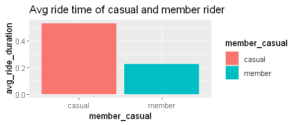

```r
### avg ride time of casual and member rider
new_df %>%
      group_by(member_casual) %>%
      summarise(avg_ride_duration=mean(duration_hr))

options(repr.plot.width = 5, repr.plot.height = 2.1)
new_df %>%
      group_by(member_casual) %>%
      summarise(avg_ride_duration=mean(duration_hr))%>%
      ggplot()+
      labs(title = "Avg ride time of casual and member rider" )+
      geom_col(mapping = aes(x=member_casual,y=avg_ride_duration,fill=member_casual))
```

#### casual riders are AVG ride time winners

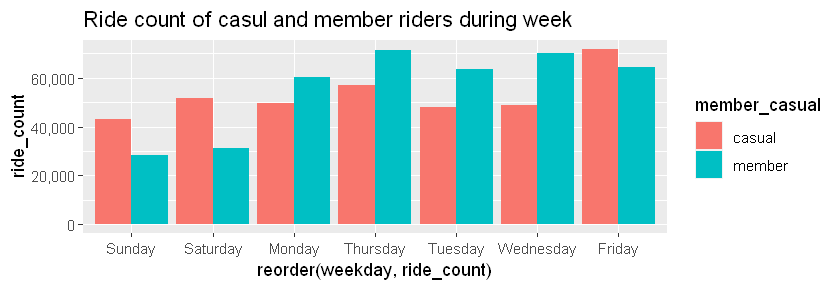

```r
### ride count of casul and member riders during week

options(repr.plot.width = 7, repr.plot.height = 2.4)
new_df %>%
      group_by(member_casual,weekday,weekend_weekday,month) %>%
      summarise(ride_count=n(),ride_duration=sum(duration_hr),avg_ride_duration=mean(duration_hr))%>%
      ggplot(mapping = aes(x=reorder(weekday,ride_count),y=ride_count,fill=member_casual))+
      labs(title = "Ride count of casul and member riders during week" )+
      geom_col(position = "dodge") +
      scale_y_continuous(labels = comma)
```

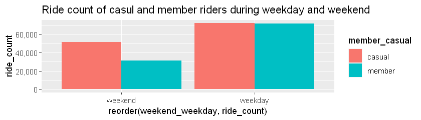

```r
### ride count of casul and member riders during weekday and weekend

options(repr.plot.width = 7, repr.plot.height = 2)
new_df %>%
      group_by(member_casual,weekday,weekend_weekday,month) %>%
      summarise(ride_count=n(),ride_duration=sum(duration_hr),avg_ride_duration=mean(duration_hr))%>%
      ggplot(mapping = aes(x=reorder(weekend_weekday,ride_count),y=ride_count,fill=member_casual))+
      labs(title = "Ride count of casul and member riders during weekday and weekend " )+
      geom_col(position = "dodge") +
      scale_y_continuous(labels = comma)
```